# Orientation: L2

## Data analysis

We load the data and remove the cases with NA values.

We have 122 subjects for a total of 1952 observations. The subjects are distributed between the lists as follows:

```
Source: local data frame [2 x 2]

    List n_distinct(Subject)
  (fctr)               (int)
1      0                  74
2      1                  48
```

After removal of entries with missing data due to wrong answers, we have 118 subjects and 1476 observations left. The subjects are distributed between the lists as follows:

```
Source: local data frame [2 x 2]

    List n_distinct(Subject)
  (fctr)               (int)
1      0                  72
2      1                  46
```

# Model Building

We consider the following independent variables:

1. `LeaYrs` a numerical variable with values ranging from 1 to 16. Learning in years.
2. `Pre` a percentage scaled to lay between 0 and 10. It indicates the previous knowledge.
3. `Post` a percentage scaled to lay between 0 and 10. It indicates the post test proficency.
4. `AECI` a numerical variable with values ranging from 1 to 5.
5. `DUH` a numerical variable with values ranging from 0 to 11.5. L2 use in hours per day.

Our base model is the following: `lmm <- lmer(log(Time) ~ Type + LeaYrs + Pre + Post + AECI + DUH + (1 | List:Subject) + (1 | List:Type:Trial), data = DLM)`

```r
lmm <- lmer(log(Time) ~  Type + LeaYrs + Pre + Post + AECI + DUH + (1 | List:Subject) + (1 | List:Type:Trial), data = DLM, REML=FALSE)
#summary(lmm)
```

```r
lmm.0 <- lm(log(Time) ~  Type + LeaYrs + Pre + Post + AECI + DUH, data = DLM)
lmm.1 <- lmer(log(Time) ~ Type + LeaYrs + Pre + Post + AECI + DUH + (1 | List:Subject), data = DLM, REML=FALSE)
lmm.2 <- lmer(log(Time) ~ Type + LeaYrs + Pre + Post + AECI + DUH + (1 | List:Type:Trial), data = DLM, REML=FALSE)
AIC(lmm.0,lmm.1,lmm.2)
```

```
      df  AIC
lmm.0  8 2152
lmm.1  9 1969
lmm.2  9 2075
```

```r
lmm.4 <- update(lmm,.~.-(1 | List:Subject))
anova(lmm.4,lmm)
```

```
Data: DLM
Models:
lmm.4: log(Time) ~ Type + LeaYrs + Pre + Post + AECI + DUH + (1 | List:Type:Trial)
lmm: log(Time) ~ Type + LeaYrs + Pre + Post + AECI + DUH + (1 | List:Subject) +
lmm:     (1 | List:Type:Trial)
      Df  AIC  BIC logLik deviance Chisq Chi Df Pr(>Chisq)
lmm.4  9 2075 2122  -1028     2057
lmm   10 1853 1906   -916     1833   224      1     <2e-16 ***
---
Signif. codes:  0 '***' 0.001 '**' 0.01 '*' 0.05 '.' 0.1 ' ' 1
```

```r
lmm.5 <- update(lmm,.~.-(1 | List:Type:Trial))
anova(lmm.5,lmm)
```

```
Data: DLM
Models:
lmm.5: log(Time) ~ Type + LeaYrs + Pre + Post + AECI + DUH + (1 | List:Subject)
lmm: log(Time) ~ Type + LeaYrs + Pre + Post + AECI + DUH + (1 | List:Subject) +
lmm:     (1 | List:Type:Trial)
      Df  AIC  BIC logLik deviance Chisq Chi Df Pr(>Chisq)
lmm.5  9 1969 2016   -975     1951
lmm   10 1853 1906   -916     1833   118      1     <2e-16 ***
---
Signif. codes:  0 '***' 0.001 '**' 0.01 '*' 0.05 '.' 0.1 ' ' 1
```

We then consider which fixed effects to include in the model.

### Heuristic Search

We use a manual, step-forward procedure with likelihood ratio test to prepare an initial model for exhaustive search.

```r
lmm.0 <- lmer(log(Time) ~  (1 | List:Subject) + (1 | List:Type:Trial), data = DLM)

lmm.1 <- update(lmm.0, .~. + Type)
anova(lmm.0,lmm.1)
```

```
Data: DLM
Models:
lmm.0: log(Time) ~ (1 | List:Subject) + (1 | List:Type:Trial)
lmm.1: log(Time) ~ (1 | List:Subject) + (1 | List:Type:Trial) + Type
      Df  AIC  BIC logLik deviance Chisq Chi Df Pr(>Chisq)
lmm.0  4 1857 1878   -925     1849
lmm.1  5 1859 1886   -925     1849     0      1       0.95
```

```r
lmm.2 <- update(lmm.0, .~.+LeaYrs)
anova(lmm.0,lmm.2)
```

```
Data: DLM
Models:
lmm.0: log(Time) ~ (1 | List:Subject) + (1 | List:Type:Trial)
lmm.2: log(Time) ~ (1 | List:Subject) + (1 | List:Type:Trial) + LeaYrs
      Df  AIC  BIC logLik deviance Chisq Chi Df Pr(>Chisq)
lmm.0  4 1857 1878   -925     1849
lmm.2  5 1851 1878   -921     1841  7.96      1     0.0048 **
---
Signif. codes:  0 '***' 0.001 '**' 0.01 '*' 0.05 '.' 0.1 ' ' 1
```

```r
lmm.3 <- update(lmm.0, .~. + Post)
anova(lmm.0,lmm.3)
```

```
Data: DLM
Models:
lmm.0: log(Time) ~ (1 | List:Subject) + (1 | List:Type:Trial)
lmm.3: log(Time) ~ (1 | List:Subject) + (1 | List:Type:Trial) + Post
      Df  AIC  BIC logLik deviance Chisq Chi Df Pr(>Chisq)
lmm.0  4 1857 1878   -925     1849
lmm.3  5 1856 1882   -923     1846  3.42      1      0.065 .
---
Signif. codes:  0 '***' 0.001 '**' 0.01 '*' 0.05 '.' 0.1 ' ' 1
```

```r
lmm.3 <- update(lmm.0, .~. + Pre)
anova(lmm.0,lmm.3)
```

```
Data: DLM
Models:
lmm.0: log(Time) ~ (1 | List:Subject) + (1 | List:Type:Trial)
lmm.3: log(Time) ~ (1 | List:Subject) + (1 | List:Type:Trial) + Pre
      Df  AIC  BIC logLik deviance Chisq Chi Df Pr(>Chisq)
lmm.0  4 1857 1878   -925     1849
lmm.3  5 1859 1886   -925     1849   0.1      1       0.75
```

```r
lmm.3 <- update(lmm.0, .~. + Post)
anova(lmm.0,lmm.3)
```

```
Data: DLM
Models:
lmm.0: log(Time) ~ (1 | List:Subject) + (1 | List:Type:Trial)
lmm.3: log(Time) ~ (1 | List:Subject) + (1 | List:Type:Trial) + Post
      Df  AIC  BIC logLik deviance Chisq Chi Df Pr(>Chisq)
lmm.0  4 1857 1878   -925     1849
lmm.3  5 1856 1882   -923     1846  3.42      1      0.065 .
---
Signif. codes:  0 '***' 0.001 '**' 0.01 '*' 0.05 '.' 0.1 ' ' 1
```

```r
lmm.4 <- update(lmm.0, .~. + AECI)
anova(lmm.0,lmm.4)
```

```
Data: DLM
Models:
lmm.0: log(Time) ~ (1 | List:Subject) + (1 | List:Type:Trial)
lmm.4: log(Time) ~ (1 | List:Subject) + (1 | List:Type:Trial) + AECI
      Df  AIC  BIC logLik deviance Chisq Chi Df Pr(>Chisq)
lmm.0  4 1857 1878   -925     1849
lmm.4  5 1858 1885   -924     1848  0.91      1       0.34
```

```r
lmm.5 <- update(lmm.0, .~. + DUH)
anova(lmm.0,lmm.5)
```

```
Data: DLM
Models:
lmm.0: log(Time) ~ (1 | List:Subject) + (1 | List:Type:Trial)
lmm.5: log(Time) ~ (1 | List:Subject) + (1 | List:Type:Trial) + DUH
      Df  AIC  BIC logLik deviance Chisq Chi Df Pr(>Chisq)
lmm.0  4 1857 1878   -925     1849
lmm.5  5 1859 1885   -924     1849  0.76      1       0.38
```

```r
lmm.3 <- update(lmm.0, .~. + Pre*Post)
anova(lmm.0,lmm.3)
```

```
Data: DLM
Models:
lmm.0: log(Time) ~ (1 | List:Subject) + (1 | List:Type:Trial)
lmm.3: log(Time) ~ (1 | List:Subject) + (1 | List:Type:Trial) + Pre +
lmm.3:     Post + Pre:Post
      Df  AIC  BIC logLik deviance Chisq Chi Df Pr(>Chisq)
lmm.0  4 1857 1878   -925     1849
lmm.3  7 1852 1889   -919     1838  11.4      3     0.0099 **
---
Signif. codes:  0 '***' 0.001 '**' 0.01 '*' 0.05 '.' 0.1 ' ' 1
```

Further, we use an automatic, step-backward procedure from the package lmerTest starting from a model that includes all second order fixed factor intereactions to understand which second order interactions are likely to be relevant.

```r
lmm.6 <- lmer(log(Time) ~ (Type + List + LeaYrs + Post + Pre + AECI + DUH)^2 + (1|List) + (1 | List:Subject) + (1 | List:Type:Trial), data = DLM, na.action="na.fail",REML=FALSE)

require(lmerTest)
ft<-step(lmm.6, lsmeans.calc = TRUE)
ft
```

```
Random effects:
                Chi.sq Chi.DF elim.num p.value
List               0.0      1        1       1
List:Subject     210.2      1     kept  <1e-07
List:Type:Trial   98.3      1     kept  <1e-07

Fixed effects:
            Sum Sq Mean Sq NumDF  DenDF F.value elim.num Pr(>F)
List:DUH    0.0010  0.0010     1   97.2  0.0056        1 0.9406
LeaYrs:AECI 0.0014  0.0014     1   96.0  0.0081        2 0.9286
Pre:DUH     0.0035  0.0035     1  100.1  0.0204        3 0.8868
Type:Pre    0.0045  0.0045     1 1349.0  0.0265        4 0.8706
List:Post   0.0124  0.0124     1  103.6  0.0727        5 0.7880
Post:DUH    0.0142  0.0142     1   98.7  0.0831        6 0.7738
Post:AECI   0.0136  0.0136     1  100.9  0.0796        7 0.7785
List:AECI   0.0193  0.0193     1  102.5  0.1129        8 0.7375
LeaYrs:Pre  0.0202  0.0202     1   99.6  0.1184        9 0.7316
List:Pre    0.0238  0.0238     1  102.9  0.1395       10 0.7095
Type:Post   0.0656  0.0656     1 1381.8  0.3841       11 0.5355
LeaYrs:DUH  0.0773  0.0773     1  101.1  0.4527       12 0.5026
LeaYrs:Post 0.0729  0.0729     1  109.6  0.4268       13 0.5149
Type:AECI   0.0861  0.0861     1 1345.2  0.5043       14 0.4777
AECI:DUH    0.0917  0.0917     1  104.1  0.5371       15 0.4653
Type:LeaYrs 0.0934  0.0934     1 1336.8  0.5468       16 0.4598
Type:DUH    0.2378  0.2378     1 1369.3  1.3931       17 0.2381
DUH         0.3129  0.3129     1  111.6  1.8328       18 0.1785
Pre:AECI    0.3700  0.3700     1  109.1  2.1671       19 0.1439
AECI        0.3734  0.3734     1  105.9  2.1873       20 0.1421
List:LeaYrs 0.5632  0.5632     1  105.9  3.2984       21 0.0722
Type        0.0000  0.0000     1   28.5  0.0000     kept 0.9987
List        0.0570  0.0570     1   69.2  0.3338     kept 0.5653
LeaYrs      1.1925  1.1925     1  105.7  6.9835     kept 0.0095
Post        1.7684  1.7684     1  116.9 10.3557     kept 0.0017
Pre         1.0022  1.0022     1  129.3  5.8687     kept 0.0168
Type:List   1.1201  1.1201     1   28.5  6.5594     kept 0.0160
Post:Pre    1.1882  1.1882     1  127.3  6.9579     kept 0.0094

Least squares means:
                      Type List Estimate Standard Error   DF t-value Lower CI Upper CI p-value
Type  MATCH            1.0   NA   6.8265         0.0467 53.3   146.3     6.73     6.92  <2e-16 ***
```

[output cut: 22 more lines]

```
List 0 - 1
Type:List  MATCH 0 -  MISMATCH 0    .
Type:List  MATCH 0 -  MATCH 1       *
Type:List  MATCH 0 -  MISMATCH 1
Type:List  MISMATCH 0 -  MATCH 1
Type:List  MISMATCH 0 -  MISMATCH 1
Type:List  MATCH 1 -  MISMATCH 1    .
---
Signif. codes:  0 '***' 0.001 '**' 0.01 '*' 0.05 '.' 0.1 ' ' 1

Final model:
lme4::lmer(formula = log(Time) ~ Type + List + LeaYrs + Post +
    Pre + (1 | List:Subject) + (1 | List:Type:Trial) + Type:List +
    Post:Pre, data = DLM, REML = reml.lmerTest.private, na.action = "na.fail",
    contrasts = l.lmerTest.private.contrast, devFunOnly = devFunOnly.lmerTest.private)
```

```r
#summary(ft$model)
#lmm<-ft$model
```

Looking at the output produced above we see which second order terms had more chances to be included in the model. We include as many of those second order terms as we can while keeping an exhaustive search feasible.

### Exhaustive search

Using the insight from the previous analysis we construct an initial model to search exhaustively.

```r
lmm.6<-lmer(log(Time) ~ Type + List + LeaYrs + Post + Pre + AECI + DUH + (1 | List:Subject) + (1 | List:Type:Trial) +
           Type:List + Pre:Post + List:LeaYrs + Pre:AECI + Type:DUH,
          data=DLM, na.action="na.fail", REML=FALSE)

library(MuMIn)
dredge.res<-dredge(lmm.6, beta = c("none"), evaluate = TRUE, rank = "AICc", fixed = NULL, m.lim = NULL,  trace = FALSE)
print(dredge.res[1:5,])
```

```
Global model call: lme4::lmer(formula = log(Time) ~ Type + List + LeaYrs + Post +
    Pre + AECI + DUH + (1 | List:Subject) + (1 | List:Type:Trial) +
    Type:List + Pre:Post + List:LeaYrs + Pre:AECI + Type:DUH,
    data = DLM, REML = FALSE, na.action = "na.fail")
---
Model selection table
     (Int)    AEC    DUH     LYr Lst    Pst     Pre Typ AEC:Pre LYr:Lst Lst:Typ Pst:Pre df logLik
3838  7.48 0.1925        -0.0531   + -0.128 -0.1109   + -0.0242       +       +  0.0228 14   -908
3840  7.45 0.1980 0.0185 -0.0557   + -0.127 -0.0967   + -0.0283       +       +  0.0226 15   -907
3711  8.15        0.0191 -0.0528   + -0.121 -0.2003   +               +       +  0.0220 13   -909
3710  7.96 0.0539        -0.0519   + -0.122 -0.1945   +               +       +  0.0216 13   -909
3709  8.17               -0.0495   + -0.124 -0.2036   +               +       +  0.0227 12   -910
     AICc delta weight
3838 1844  0.00  0.223
3840 1844  0.08  0.214
3711 1844  0.24  0.198
3710 1844  0.26  0.195
3709 1845  0.53  0.170
Models ranked by AICc(x)
Random terms (all models):
'1 | List:Subject', '1 | List:Type:Trial'
```

```r
attr(dredge.res, "model.calls")[1]
```

```
$`3838`
lme4::lmer(formula = log(Time) ~ AECI + LeaYrs + List + Post +
    Pre + Type + (1 | List:Subject) + (1 | List:Type:Trial) +
    AECI:Pre + LeaYrs:List + List:Type + Post:Pre, data = DLM,
    REML = FALSE, na.action = "na.fail")
```

Or in a pretty table form:

(Intercept)

AECI

DUH

LeaYrs

List

Post

Pre

Type

AECI:Pre

DUH:Type

LeaYrs:List

List:Type

Post:Pre

df

logLik

AICc

delta

weight

3838

7.48

0.19

-0.05

-0.13

-0.11

-0.02

0.02

14

-907.9

1844.0

0.0

0.22

3840

7.45

0.20

0.02

-0.06

-0.13

-0.10

-0.03

0.02

15

-906.9

1844.1

0.1

0.21

3711

8.15

0.02

-0.05

-0.12

-0.20

0.02

13

-909.0

1844.3

0.2

0.20

3710

7.96

0.05

-0.05

-0.12

-0.19

0.02

13

-909.0

1844.3

0.3

0.20

3709

8.17

-0.05

-0.12

-0.20

0.02

12

-910.2

1844.6

0.5

0.17

The final model on which we base our exhaustive search is:

```r
lmm <- lmer(formula = log(Time) ~ AECI + LeaYrs + List + Post + Pre +
    Type + (1 | List:Subject) + (1 | List:Type:Trial) + AECI:Pre +
    LeaYrs:List + List:Type + Post:Pre, data = DLM, REML = FALSE)
```

See below, in the Anova section, the summary of this model.

## Diagnostic plots

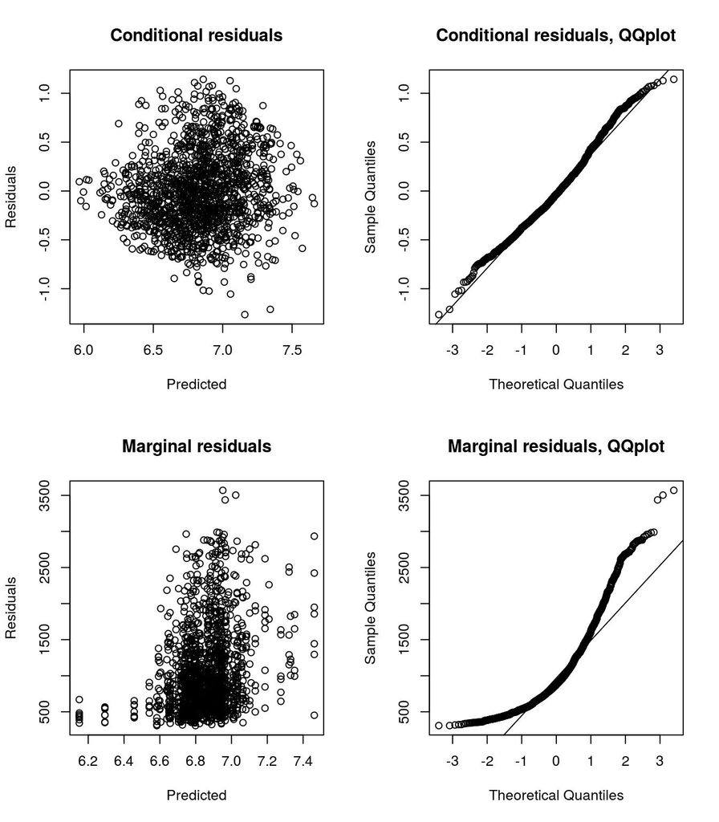

```r
par(mfrow=c(2,2))
# plot(lm4,which=1:4)

plot(fitted(lmm, Type = "response"), residuals(lmm, Type = "response"),
     main = "Conditional residuals", xlab = "Predicted", ylab = "Residuals")

res <- residuals(lmm, Type = "response")
qqnorm(res, main = "Conditional residuals, QQplot")
qqline(res)

lmm.0 <- lm(formula = log(Time) ~ AECI + LeaYrs + List + Post + Pre + Type + AECI:Pre +
    LeaYrs:List + List:Type + Post:Pre, data = DLM)
#lm.0 <- update(lmm,.~.-(1 | List:Subject) - (1 | List:Type:Trial))
x <- model.matrix(lmm.0)
pred <- x %*% fixef(lmm)
res <- DLM$Time - pred
plot(pred, res, main = "Marginal residuals", xlab = "Predicted", ylab = "Residuals")
qqnorm(res, main = "Marginal residuals, QQplot")
qqline(res)
```

The joint qqplot looks normal. The marginal looks less nice.

## p-values

Anova of type III with Satterwhite Approximation:

```r
require(lmerTest)
anova(lmm)
```

```
Analysis of Variance Table of type III  with  Satterthwaite
approximation for degrees of freedom
            Sum Sq Mean Sq NumDF DenDF F.value  Pr(>F)
AECI         0.667   0.667     1 118.7    3.91 0.05045 .
LeaYrs       1.013   1.013     1 111.1    5.93 0.01645 *
List         0.556   0.556     1 131.3    3.26 0.07345 .
Post         2.213   2.213     1 123.0   12.96 0.00046 ***
Pre          0.242   0.242     1 132.6    1.42 0.23601
Type         0.000   0.000     1  32.4    0.00 0.98377
AECI:Pre     0.397   0.397     1 117.4    2.33 0.12994
LeaYrs:List  0.598   0.598     1 112.0    3.50 0.06393 .
List:Type    1.236   1.236     1  32.4    7.24 0.01119 *
Post:Pre     1.445   1.445     1 135.1    8.46 0.00424 **
---
Signif. codes:  0 '***' 0.001 '**' 0.01 '*' 0.05 '.' 0.1 ' ' 1
```

and the effects with the t test:

```r
summary(lmm)
```

```
Linear mixed model fit by maximum likelihood t-tests use Satterthwaite approximations to degrees
  of freedom [lmerMod]
Formula: log(Time) ~ AECI + LeaYrs + List + Post + Pre + Type + (1 | List:Subject) +
    (1 | List:Type:Trial) + AECI:Pre + LeaYrs:List + List:Type +      Post:Pre
   Data: DLM

     AIC      BIC   logLik deviance df.resid
    1844     1918     -908     1816     1462

Scaled residuals:
    Min      1Q  Median      3Q     Max
-3.0611 -0.6715 -0.0816  0.5898  2.7661

Random effects:
 Groups          Name        Variance Std.Dev.
 List:Subject    (Intercept) 0.0516   0.227
 List:Type:Trial (Intercept) 0.0181   0.135
 Residual                    0.1708   0.413
Number of obs: 1476, groups:  List:Subject, 118; List:Type:Trial, 32

Fixed effects:
                    Estimate Std. Error        df t value Pr(>|t|)
(Intercept)          7.47978    0.47884 128.90000   15.62  < 2e-16 ***
AECI                 0.19247    0.09739 118.70000    1.98  0.05045 .
LeaYrs              -0.05309    0.01476 109.70000   -3.60  0.00049 ***
List1               -0.32544    0.11423 110.90000   -2.85  0.00523 **
Post                -0.12761    0.03545 123.00000   -3.60  0.00046 ***
Pre                 -0.11088    0.09314 132.60000   -1.19  0.23601
TypeMISMATCH        -0.14287    0.07293  29.70000   -1.96  0.05958 .
AECI:Pre            -0.02424    0.01589 117.40000   -1.53  0.12994
LeaYrs:List1         0.04568    0.02441 112.00000    1.87  0.06393 .
List1:TypeMISMATCH   0.28358    0.10540  32.40000    2.69  0.01119 *
Post:Pre             0.02279    0.00783 135.10000    2.91  0.00424 **
---
Signif. codes:  0 '***' 0.001 '**' 0.01 '*' 0.05 '.' 0.1 ' ' 1

Correlation of Fixed Effects:
            (Intr) AECI   LeaYrs List1  Post   Pre    TMISMA AECI:P LYr:L1 L1:TMI
AECI        -0.716
LeaYrs      -0.029 -0.088
List1       -0.124 -0.044  0.368
Post        -0.597 -0.087 -0.012  0.085
Pre         -0.907  0.574  0.009  0.027  0.623
TypMISMATCH -0.070 -0.005  0.000  0.320 -0.004 -0.009
AECI:Pre     0.656 -0.933  0.052  0.074  0.107 -0.590  0.005
LeaYrs:Lst1  0.084  0.037 -0.590 -0.659 -0.067 -0.037  0.000 -0.069
L1:TMISMATC  0.046  0.002  0.000 -0.454  0.007  0.008 -0.692 -0.001 -0.001
Post:Pre     0.582  0.057 -0.039 -0.093 -0.895 -0.736  0.007 -0.097  0.091 -0.008
```

We also include the analysis via `merTools` package that calculates simulated values of the (fixed and random) effects from the posterior using the function `arm::sim`:

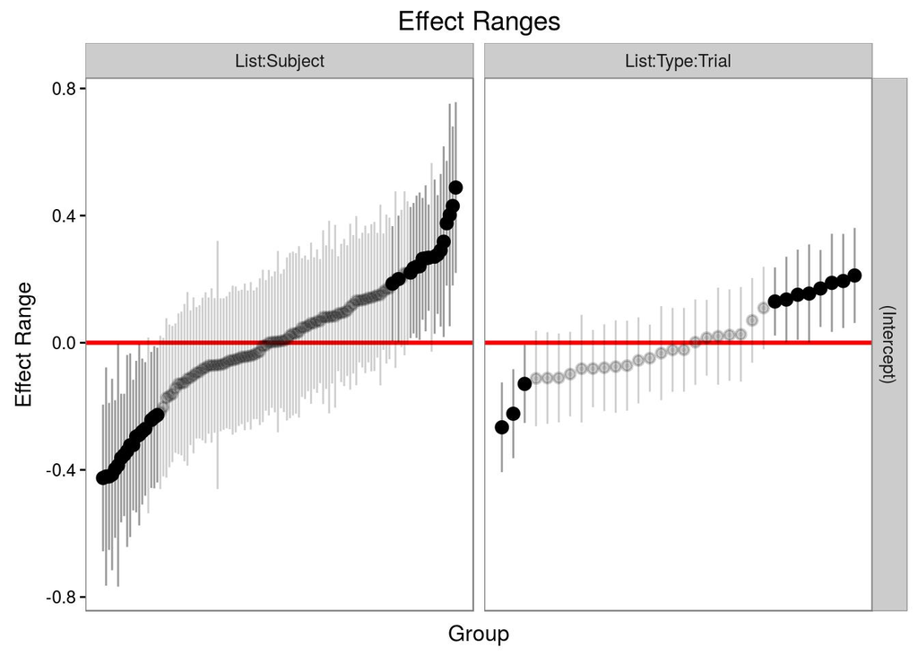

```r
detach("package:lmerTest",unload=TRUE)
require(merTools)
lmm <- lmer(formula = log(Time) ~ AECI + LeaYrs + List + Post + Pre +
    Type + (1 | List:Subject) + (1 | List:Type:Trial) + AECI:Pre +
    LeaYrs:List + List:Type + Post:Pre, data = DLM, REML = FALSE)
plotREsim(REsim(lmm, n.sims= 100), level=0.95, stat="mean")
```

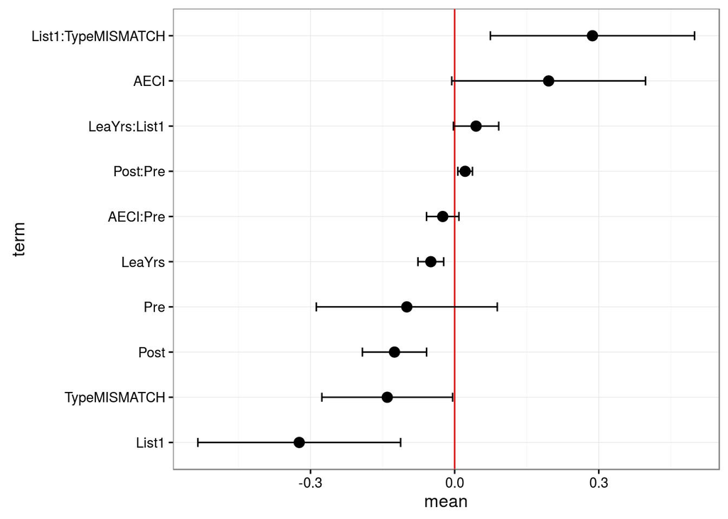

```r
plotFEsim(FEsim(lmm, n.sims = 100), level = 0.95, stat = 'mean', intercept = FALSE)
```

## Conclusions

The figures below show random and the fixed effects. The random effects show that the different subjects imply a significantly different intercept. In the plot of the fixed effects, we back transformed the effects in linear scale and added 0.95-confidence level bands.

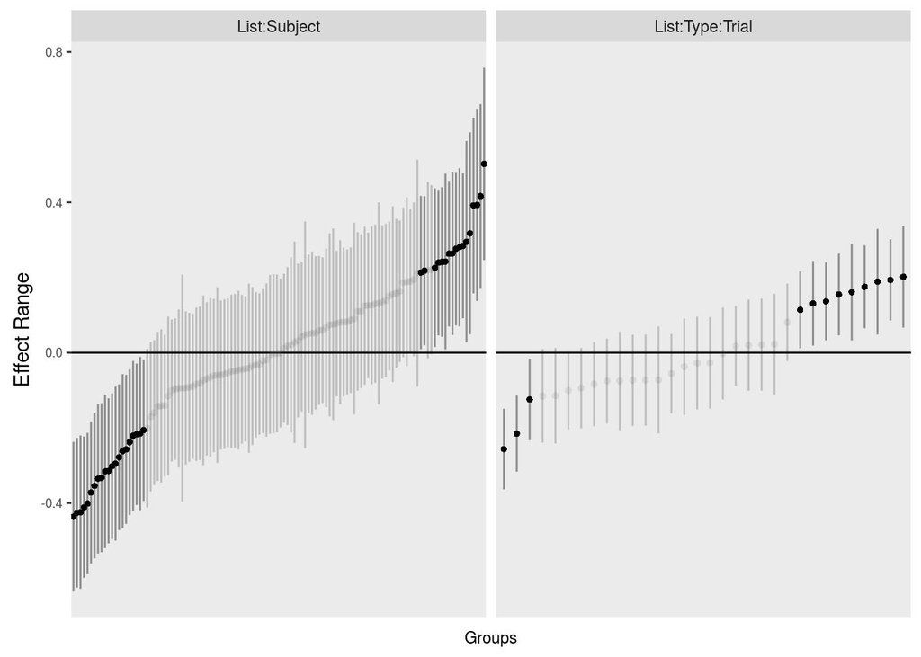

For the fixed effects we plot all plots relative to statistically significant terms. The instructive plots are the main effect of `LeaYrs` and the interaction between `Post` and `Pre`, which, we deem, explains the significance of the `Post` term as well.

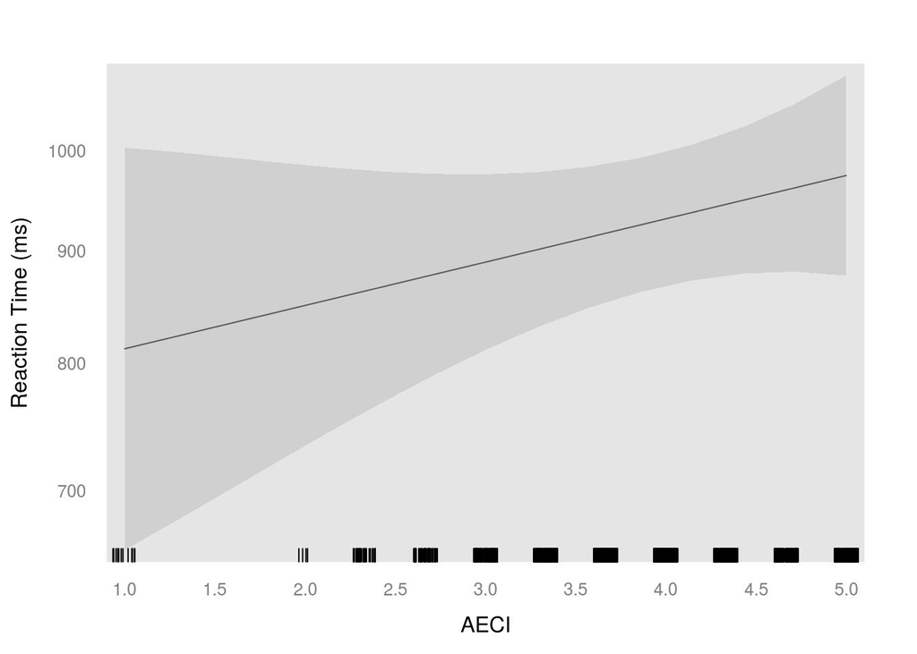

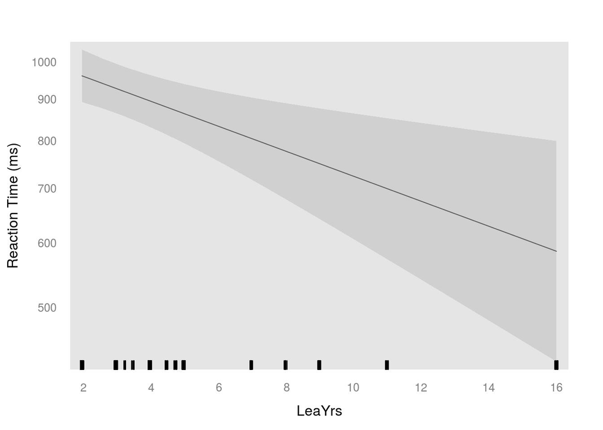

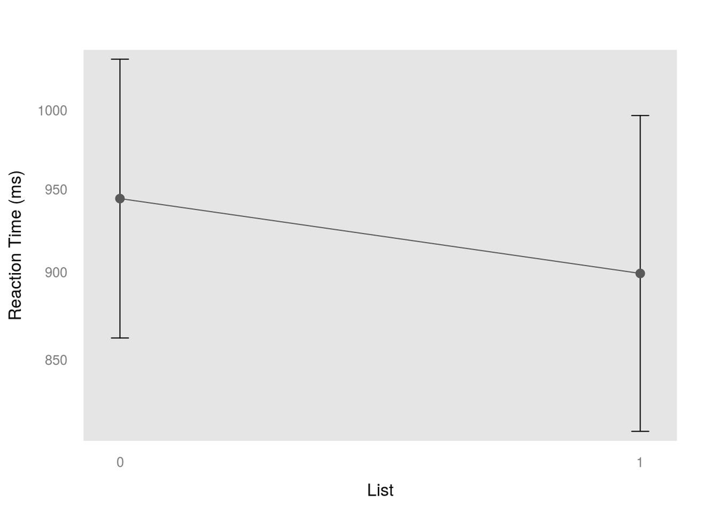

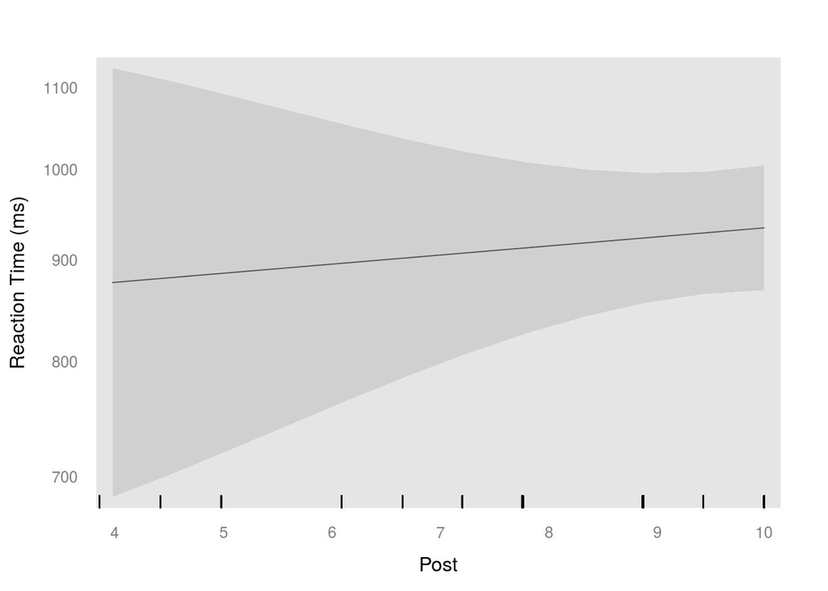

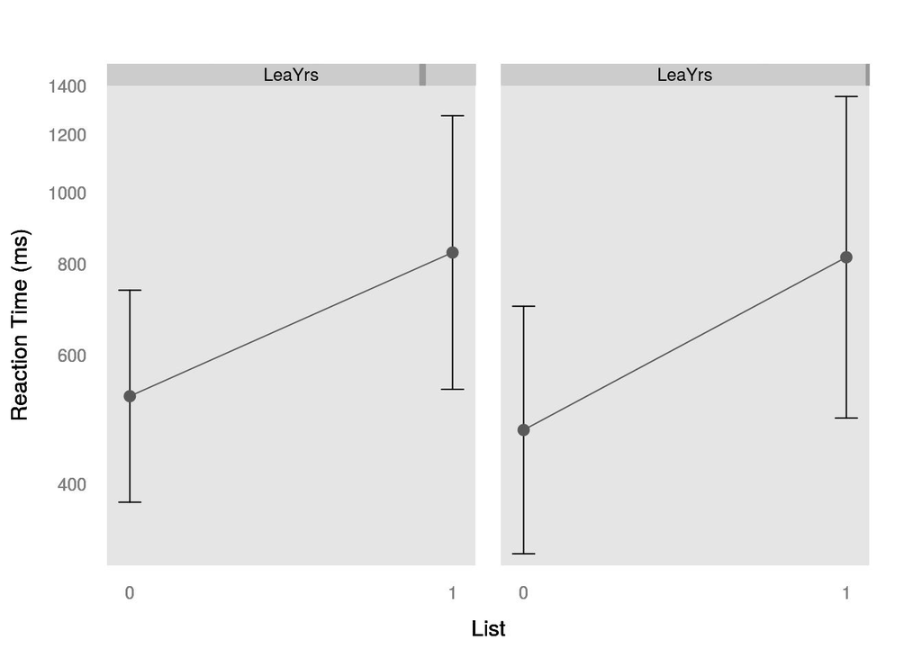

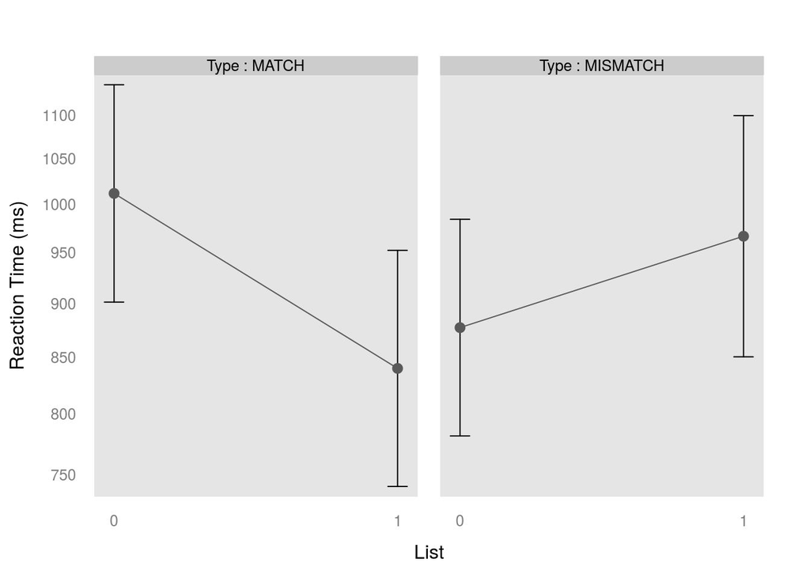

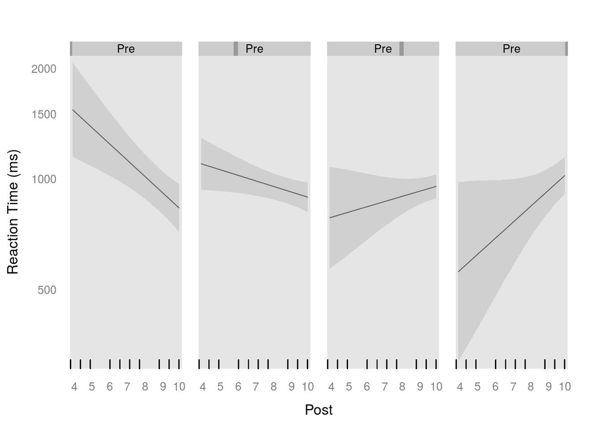

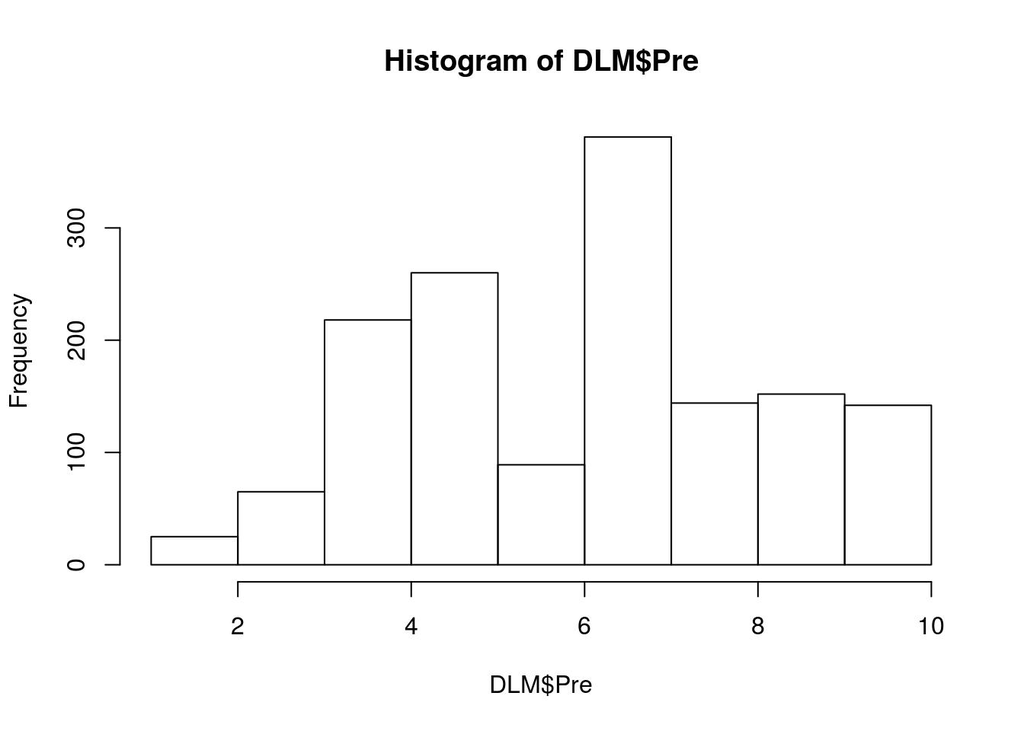

Plot of the coefficient estimates of one variable conditional on the values of the other variable in the interaction term.

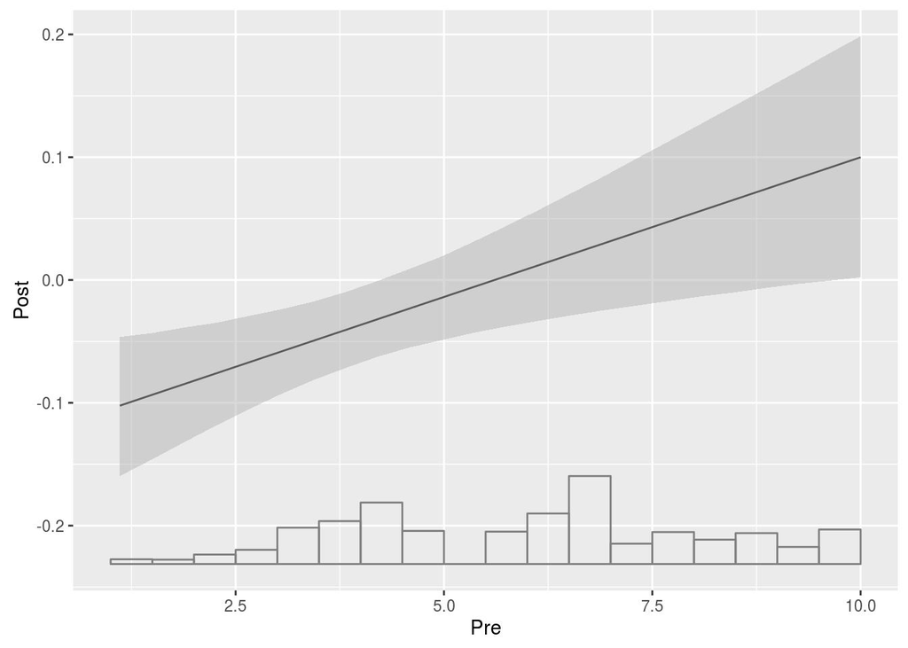